# Children’s emotional regulation

Abigail E. Page<sup>1</sup> abigail.page@brunel.ac.uk

<sup>1</sup> Department of Psychology, Brunel University of London

# Introduction

Children’s ability to regulate emotions improves as they grow, but the pace and patterns of this development vary. This study examines how emotional regulation scores differ across age groups in a sample of children aged 5–12. We expect older children to be able to regulate their emotions better than younger children.

# Methods

## Participants and Data

Data were collected from a sample of children aged 60-150 months, each of whom completed an emotional regulation assessment in an online survey alongside demographic data. The dataset included children’s age in months and an emotional regulation score.

## Data Preparation

Age in months was converted into years (including decimal points) to make results easier to interpret. After conversion, the dataset was cleaned by removing any remaining missing values.

```r
# emotional_regulation is too long name. rename it.
df <- df %>%
  rename( # function rename
    emoreg = emotional_regulation)
# variable now called 'emoreg'

# mutate the months variable into age
df <- df %>%
  mutate(age = (months/12))
# age is the new variable which is months
# variable divided by 12

# Check for missing values in key variables
colSums(is.na(df[, c("age", "emoreg")]))
```

```
##    age emoreg
##      1      2
```

```r
# There are one missing in age and 2 in emoreg
# Remove missing values ONLY for relevant variables

df_clean <- df %>%
  drop_na(age, emoreg)
```

## Linear Regression

A simple linear regression was conducted to examine whether age predicted emotional regulation. A scatterplot with 95% confidence intervals were included. Model assumptions were assessed using a Q-Q plot to explore the normality of residuals.

# Results

**Table 1. Summary Statistics for Age and Emotional Regulation**

```
##   Mean_Age  SD_Age Mean_ER    SD_ER
## 1     8.35 2.10534   8.441 2.270917
```

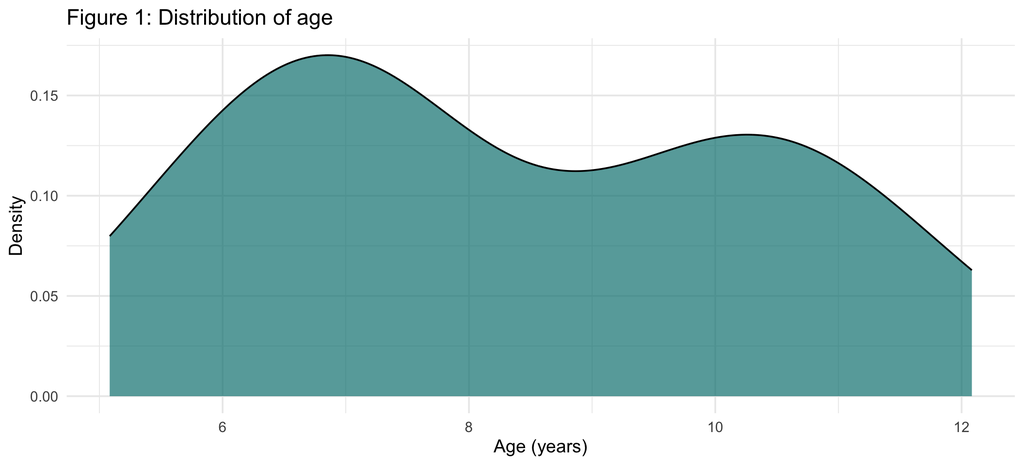

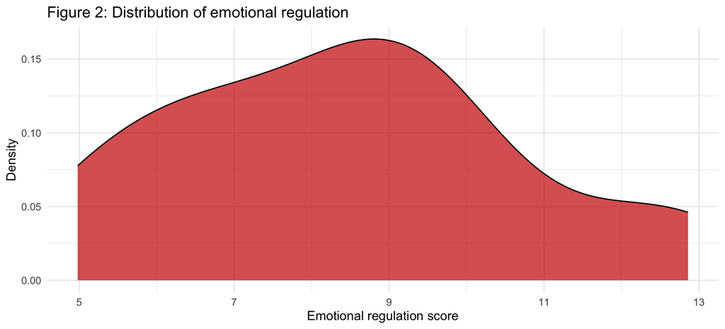

```
##             Estimate Std. Error t value Pr(>|t|)
## (Intercept)    1.915      1.507   1.271     0.22
## age            0.782      0.175   4.461     0.00
```

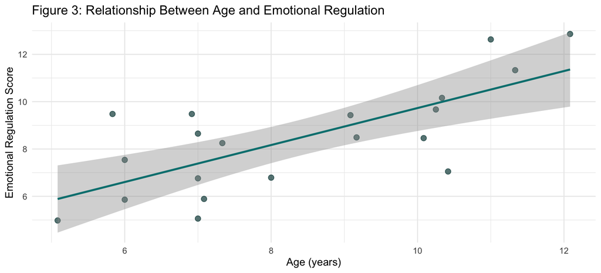

Residuals were checked for normality and Q-Q plots showed approximate normality.

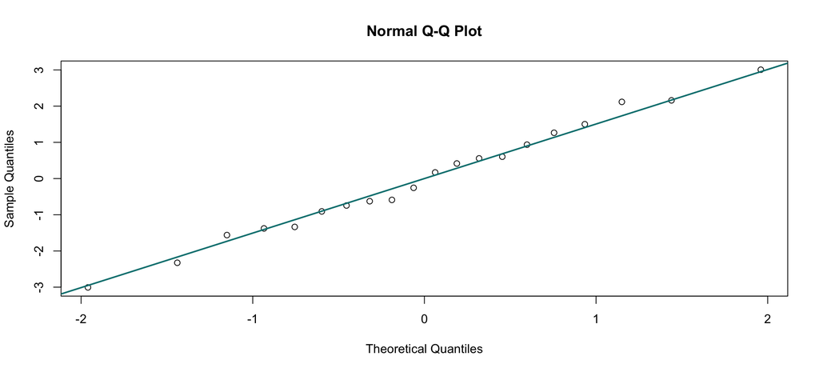

# Conclusion

This study demonstrates that emotional regulation improves with age in children aged 5-12. Older children showed stronger self-regulation compared to younger children, consistent with typical developmental trends. These findings highlight the importance of supporting emotional skills in early childhood to promote healthy development.

Older children show stronger emotional regulation than younger children.

[figure not shown]